# Tvyal Newsletter

Aghasi Tavadyan

2024-01-19

*English summary below.*

Հարգելի գործընկեր,

Հուսով եմ լավ եք: Ներկայացնում եմ այս շաբաթվա վերլուծությունները և աշխատանքները.

1. Հայաստանի “ավտոարտադրության” մահը
2. ԶԼՄ հաղորդագրություններ
3. English summary

## 1. Հայաստանի “ավտոարտադրության” մահը

2023 թվականի առաջին 10 ամիսների կտրվածքով Հայաստանի արտահանման 7.2 տոկոսը եղել է մարդատար ավտոմեքենաները։ Այսպես, Հայաստանի արտահանման 7.2 տոկոսը ապահովել է ավտոմեքենաների “արտադրությունը”։ Նշենք, որ նույն ժամանակահատվածում ավտոմեքենաների ներմուծումը կազմել է ընդհանուրի 10.5 տոկոսը։

Տնտեսության այս զգալի և համեմատաբար նոր հատվածը, որը ապահովվել է 2022 և 2023 թվականների տնտեսական աճի մի մասը մեծ խնդիրների առաջ է կանգնած և 2024 թվականին կարող է լիովին չեզոքանալ։

**Աղյուսակ 1** Հայաստանից մեքենաների արտահանումը (մլն ԱՄՆ դոլար, 1-ից 10-րդ ամիսների կտրվածքով)

Armenia’s Exports of Vehicles (mln USD, data for the first 10 months of the given year)

| partner | 2021 | pct | 2022 | pct | 2023 | pct |
| --- | --- | --- | --- | --- | --- | --- |
| Russian Federation | 2.4 | 34.8% | 120.5 | 91.8% | 354.0 | 84.8% |
| Other counties | 4.6 | 65.2% | 10.8 | 8.2% | 63.3 | 15.2% |
| Total | 7.0 | 100.0% | 131.3 | 100.0% | 417.4 | 100.0% |

Նշենք, որ 2021-ին ներմուծվել է 7362 թեթև մարդատար ավտոմեքենա (77.9 մլն դոլար), ապա 2022-ին արդեն՝ 42 293 ավտոմեքենա (360.2 մլն դոլար): Այսինքն մոտ 6 անգամ աճ է տեղի ունեցել: 2021-ին Հայաստանից արտահանվել է 319 մեքենա, իսկ 2022-ին՝ 10936 ավտոմեքենա: Այսպիսով, ներմուծված մեքենաների քառորդը վերաարտահանել է հիմնականում Ռուսաստան: Գրանցվել է ԱՄՆ-ից մեքենաների ներմուծման զգալի աճ` մոտ 7 անգամ 2022թ. ընթացքում։

Պետք է նշել, որ այստեղ տեղի չի ունենում պարզապես վերաարտահանում։ Հիմնականում Հյուսիսային Ամերիկայից վնասված մեքենաները ներմուծվում են Հայաստան, որից հետո այդ ավտոմեքենաների վրա կատարվում է որոշակի վերանորոգման աշխատանք, որը ստեղծում է ավելացված արժեք, որից հետո այն հիմնականում վերաարտահանվում է Ռուսատանի Դաշնություն՝ Հայաստանին թողնելով նաև ծառայության միջնորդավճար։

2023 թվականի ավտոմեքենաների արտահանումը առաջին 10 ամիսներին` համեմատած 2022 թվականի նույն ժամանակահատվածի հետ աճել է 3.17 անգամ, որը առաջին հայացքից ցույց է տալիս այս ոլորտի ներուժը և աճը, սակայն իրականությունն այլ է։

**Աղյուսակ 2** Հայաստանից մեքենաների ներմուծումը (մլն ԱՄՆ դոլար, 1-ից 10-րդ ամիսների կտրվածքով)

Armenia’s Imports of Vehicles (mln USD, data for the first 10 months of the given year)

| partner | 2021 | pct | 2022 | pct | 2023 | pct |
| --- | --- | --- | --- | --- | --- | --- |
| USA | 17.9 | 22.9% | 121.3 | 33.7% | 319.4 | 32.0% |
| Japan | 13.3 | 17.0% | 77.2 | 21.4% | 221.7 | 22.2% |
| Other counties | 30.5 | 39.2% | 55.7 | 15.5% | 94.2 | 9.5% |
| Germany | 6.6 | 8.5% | 36.2 | 10.1% | 108.7 | 10.9% |
| Mexico | 2.8 | 3.7% | 24.5 | 6.8% | 102.9 | 10.3% |
| Rep. of Korea | 1.4 | 1.8% | 15.4 | 4.3% | 59.9 | 6.0% |
| Canada | 4.1 | 5.3% | 15.1 | 4.2% | 41.7 | 4.2% |
| China | 1.3 | 1.6% | 14.6 | 4.1% | 48.4 | 4.9% |
| Total | 77.9 | 100.0% | 360.2 | 100.0% | 996.9 | 100.0% |

ԱՄՆ-ից ներմուծումը 2022 թվականին 2021-ի համեմատ աճել է մոտ 3,5 անգամ՝ 107 մլն դոլարից հասնելով 356 մլն դոլարի: Արտահանումը նույնն է մնացել: ԱՄՆ-ից հիմնականում ներմուծվել են ավտոմեքենաներ: Ավտոմեքենաները կազմում են ԱՄՆ-ից ներմուծման մոտ 70 տոկոսը: Մնացածը ատոմային ռեակտորներն են, դեղագործական և օպտիկական ապրանքները: [Մինչև 2022 թվականը ԱՄՆ-ի հետ մեր առևտրաշրջանառությունը մոտ 4 տոկոս էր, իսկ 2022-ին, պայմանավորված հիմնականում ավտոմեքենաների ներմուծմամբ, այդ ցուցանիշը էական աճ է գրանցել](https://www.1in.am/3253116.html)։

Հասկանալի է, որ այս ամենը վերաարտահանում է, ու որ Հայաստանից ավտոմեքենաների արտահանումն աճել է 2022 թվականից Ռուսաստանի դեմ կիրառվող պատժամիջոցներից հետո։ Որպես ԵԱՏՄ անդամ այստեղ շահել ենք, քանի որ այլ իրավիճակում իմաստ չէր լինի ավտոմեքենաները Հյուսիսային Ամերիկայից բերել Վրաստան, ապա Հայաստան, որից հետո տանել Ռուսաստան։ ԵԱՏՄ ազատ առևտրի տարածքը որոշակի օգուտներ է տվել նաև այդ մասով։

Եթե նայենք խոշոր հարկատուների ցանկը, 2022 թվականին 2021-ի համեմատ Հայաստանի ավտոներմուծողների շահութահարկը 7-ից 15 անգամ կրկնապատկվել է։ Այդ շահույթը գնացել է հետագա վերաարտահանման հույսով նոր ավտոմեքենաներ ձեռքբերելուն։

### Ի՞նչ է սպառնում Հայաստանի “ավտոարտադրությանը” 2024 թվականին

**Գծապատկեր 1.** Հայաստանի ավտոմեքենաների ներմուծումը (ամսական կտրվածքով)

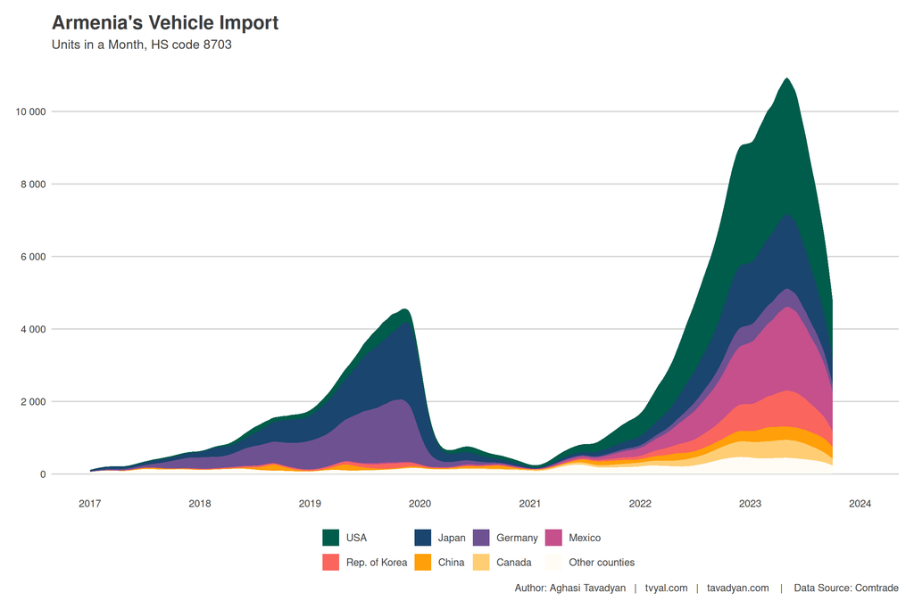

Թվում է` ամեն ինչ լավ է. ավտոմեքենաների արտահանումն աճել է 2023-ին համեմատած 22 թվականի հետ։ Սակայն իրականությունը, ինչպես գծապատկերն է ցույց տալիս, այդքան էլ դրական չէ։ Վրաստանը այս տարածաշրջանի ավտոմեքենաների հիմնական շուկան է և այդքան հեշտ չի զիջի իր մասնաբաժնի թեկուզ փոքր մասը Հայաստանին։ Նաև այդ պատճառով է, որ օգոստոսի 1-ից Թբիլիսիի իշխանություններն արգելել են 1,9 լիտր և ավելի շարժիչով ամերիկյան ավտոմեքենաների, ինչպես նաև հիբրիդային և էլեկտրական մեքենաների արտահանումը։ Հայաստանի ավտոմեքենանրի արտահանման ավելի քան 90 տոկոսը այս դասի աստոմեքենաներ էին։ Սա երևում է առաջին գծապատկերում։

Ճիշտ է 2023 թվականին 2022-ի համեմատ ավտոմեքենաների գումարային արտահանումը ավելի շատ է, սակայն 2022 թվականին ավտոմեքենաների արտահանման կտրուկ և անսպասելի աճից հետո, 2023 թվականի սկզբին գրանցվել է արտահանման գագաթնակետը, որից հետո այն կտրուկ անկում է գրանցել։

Հետաքրքիր է նաև 2019-2020 թվականներին նույնպես գրանցվեց ավտոմեքենաների ներմուծման հանկարծակի աճ և տարեվերջյան անկում։ Այս անկումը հիմնականում անդրադարձել է ճապոնական մեքենաների ներմուծման կրճատման վրա: Որի հիմնական պատճառը ԵԱՏՄ տարածքում ավտոմեքենաների ներմուծման նոր դրույքաչափերի ներդրումն էր, ըստ որի ավելի քան 3 տարի առաջ արտադրված մեքենաների վրա գործում էր զգալի դրույքաչափ, որը տնտեսապես ձռնտու չէր: Սա 2020 թվականին չեզոքացրեց այս ճյուղը և այդ տարի ավտոմեքենաների ներմուծում գրեթե չի գրանցվել։

**Գծապատկեր 2.** Հայաստանի ավտոմեքենաների արտահանումը և ներմուծումը (ամսական կտրվածքով)

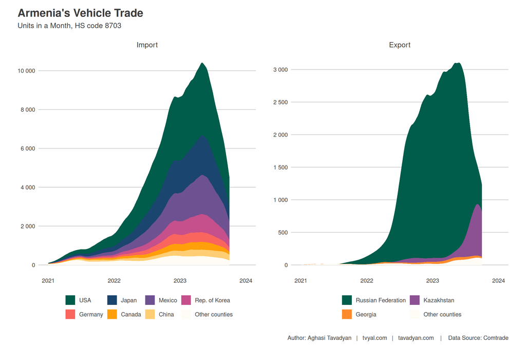

2022-23 թվականներին Հայաստանը, Վրաստանից հետո տարածաշրջանի ամենախոշոր երկրորդ ավտոշուկան էր։ Հայաստանի մեծածավալ արտահանումը որոշակի խնդիրներ առաջացրեց Վերին Լարսի սահմանին, բացի այդ ըստ բիզնեսի կանոնների հաստատված շուկան դժվար թե կամենա այլ շուկաների ասպարեզ արագ դուրս գալը։ Այստեղ նաև առկա է որոշակի քաղաքական գործոն։

2023 թվականի առաջին 10 ամիսների ընթացքում Հայաստանից արտահանվել է 18 835 ավտոմեքենա (ներմուծվել՝ 70 859), ամբողջ 2022 թվականին արտահանվել է 10 936 ավտոմեքենա (ներմուծվել՝ 42 293)։ 2023 թվականին բոլոր պետությունների շարքում արտահանման ծավալներով ամենախոշոր 35֊րդ արտահանողը կլինի Հայաստանը, իսկ Վրաստանը մոտ 25-րդ տեղում։ Վրաստանը 2023-ին արտահանել է մոտ 100 հազար ավտոմեքենա։

Մեր շուկա բավականին մեծ քանակությամբ մեքենա է մտել, ինչը լցրել է մաքսակետերը ու ներմուծողների ավտոկայանատեղիները։ Իսկ ավտոմեքենան այնպիսի ապրանք է, որ ժամանակի ընթացքում արժեզրկվում է։

Կարելի է սպասել, որ 2024 թվականին ավտոներմուծողները ստիպված են լինելու վնասով մեծ քանակությամբ ավտոմեքենաներ վաճառել ներքին շուկայում, այսինքն կարող է մեքենաների գները այս տարի բավականին իջնեն։ Սա կարող է մեծացնել ավտոմեքենաների թվաքանակը Երևանի փողոցներում, ինչը տեղի ունեցավ 2020 թվականին։

3-րդ գծապատկերում ցուցադրված է Վրաստանի ավտոմեքենաների ամսական արտահանումը և ներմուծումը ըստ տարբեր երկրների։ Վրաստանը մեծ քանակությամբ մեքենաներ չի արտահանում դեպի Ռուսաստան և դեպի Ռուսատան արտահանումը 2023 թվականի օոգոստոսից գրեթե դադարեց, ինչպես այն դադարեց Հայաստանում։ Հիմնականում Վրաստան ներմուծվում են մեքենաներ ԱՄՆ-ից և արտահանվում Ադրբեջան և Ղազախստան։ Հուշագրավ է նաև այն, որ 2023 թվականի կեսերից դեպի Վրաստան ավտոմեքենաների և՛ արտահանումը, և՛ ներմուծումը կանգնել է, որը նույնպես խոսում է այս շուկայի հագեցվածության և շուկայում խնդիրների մասին։

**Գծապատկեր 3.** Վրաստանի ավտոմեքենաների արտահանումը և ներմուծումը (ամսական կտրվածքով)

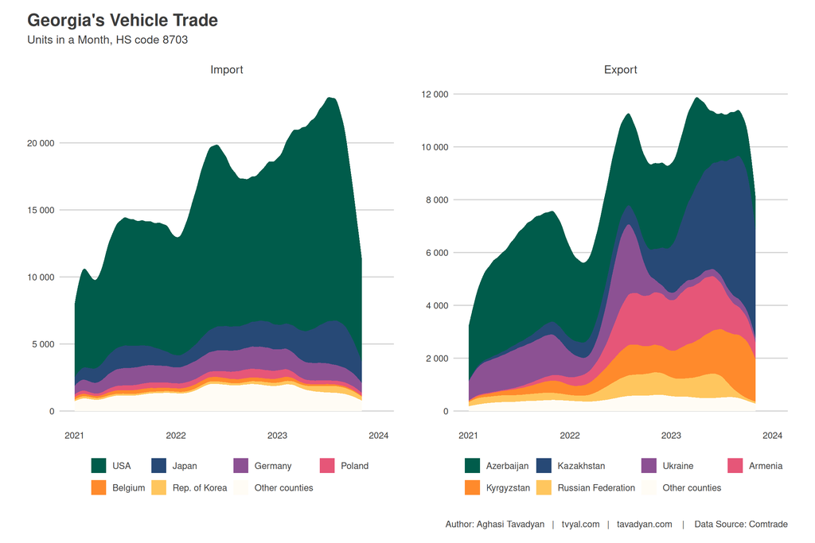

### Ռուսաստանն էլ չի կամենում վերաարտահանված մեքենաներ

2023 թվականին Ռուսաստանում վաճառված [յուրաքանչյուր 8-րդ մեքենան ներմուծվել է “գորշ” ներմուծմամբ](https://carsweek.ru/news/News_in_the_world/1277489/)։ 2023 թվականի հունվարից սեպտեմբեր ՌԴ քաղաքացիները ձեռք են բերել ավելի քան 100 հազար ավտոմեքենա, որոնք ռուսական ավտոշուկա են մտել “գորշ” ներմուծման միջոցով։ Սեպտեմբերին նրանց շուկայական մասնաբաժինը օգոստոսի համեմատ նվազել է 13%-ից մինչև 11%։

Սեպտեմբեր ամսին “գորշ” ներմուծման ճանապարհով առավել հաճախ ՌԴ են բերվել [ճապոնական (4,4 հազար հատ, 34 տոկոս), կորեական (3,1 հազար հատ, 24 տոկոս) և գերմանական (2,7 հազար հատ, 20 տոկոս) ավտոմեքենաներ։ Չինական արտասահմանյան մեքենաների մասնաբաժինը նույնպես դրական դինամիկա է ցույց տալիս՝ օգոստոսի 7%-ից սեպտեմբերին հասնելով 12%-ի](https://www.autonews.ru/news/6501a9ec9a794705e42162ba):

2023 թվականի հոկտեմբերի 1-ից Ռուսաստանում փոխվել են մեքենաների “գորշ” կամ զուգահեռ ներմուծման կանոնները։ Այս տեսակի ներմուծումը սահմանափակվել է։ Այժմ նման մեքենաները ներկրվում են փոքր ընկերությունների կողմից և ավելի մատչելի են, քան պաշտոնական ավտոսրահներում։ Սա ձեռք չի տալիս Ռուսաստանի տնտեսությանը որը փորձում է զարգացնել իր ներքին արտադրությունը և առավելություն է տալիս այն ավտոմեքենաներին, որոնք արտադրվել են ՌԴ տարածքում։

Օգոստոսի 1-ից դեպի Ռուսատան “գորշ” ճանապարհով ավտոմեքենաների ներմուծման համար գործում է նաև վերամշակման արտոնյալ վճար, որը թույլ չի տալիս անձին տարեկան մեկից ավելի մեքենա ներկրել Ռուսատան և այն վաճառել մեկ տարվա ընթացքում։

Այս ամենը մեծ հավանականությամբ հանգեցնելու է 2024թ․ ներմուծման և արտահանման զգալի չափաբաժնի կորստին, որը կարող է նաև անդրադառնալ ՀՆԱ-ի աճի վրա։

## 2. ԶԼՄ հաղորդագրություններ

🇦🇲🇷🇺Հայաստան-Ռուսաստան առևտուրը․ օգուտն ու պատժամիջոցների տակ հայտնվելու ռիսկերը 🌐

🔗 Կարդացեք իմ վերջին հարցազրույցը, տրված jam-news կայքին։ Հարցազրույցը հասանելի է նաև Անգլերեն և ռուսերեն տարբերակներով։

🔍 Հիմնական կետերը.

- 📈 Հայաստանի արտահանման ցուցանիշի կտրուկ աճ՝ Հայաստանը Ռուսաստան է արտահանում ապրանքների կեսից ավելին՝ 52 տոկոսը։
- 🔄 Արտահանման փոփոխություն, ներառյալ ռադիո սարքավորումների, հեռախոսների, մեքենաների, մոնիտորների, պրոյեկտորների, ընդունիչ սարքավորումների, հեռուստացույցների և համակարգիչների արտահանման զգալի աճ:
- 📊 Տեխնիկական սարքավորումներ արտահանող ընկերությունների թվի աճ։
- 🇺🇸 Ռուսաստանի հետ առևտրով զբաղվող հայկական կազմակերպությունների նկատմամբ ԱՄՆ-ի հնարավոր պատժամիջոցների քննարկում։

[figure not shown]

## 3. English Summary

**The Death of Armenia’s “Auto-industry”**

In the first 10 months of 2023, Armenia witnessed a 3.17-fold increase in car exports compared to the same period in 2022. However, this seemingly positive trend masks the underlying challenges. Georgia, has implemented restrictions on the export of American cars with engines of 1.9 liters and more, as well as hybrid and electric cars, constituting over 90% of Armenia’s automobile exports. Consequently, after a peak in early 2023, a sharp decline in exports has been recorded. Furthermore, Russia, a significant destination for re-exported cars from Armenia, has tightened regulations on “grey” imports, impacting the market. As a result, experts predict that in 2024, car importers in Armenia may face substantial losses, potentially leading to a significant drop in car prices in the domestic market. This situation poses a threat to the overall economic landscape, as the auto reexports played a some role in Armenia’s economic growth in 2022 and 2023.

## Այս վերլուծությունը առկա է նաև [մեր կայքէջում](https://www.tvyal.com/newsletter/2024/2024_01_19), այս վերլուծության կոդը և տվյալները դրված են նաև [Github-ում](https://github.com/tavad/tvyal_newsletter)։

Եթե հնարավոր է, խնդրում եմ այս նյութը ուղարկել նաև այն մարդկանց, ում այն կարծում եք կարող է հետաքրքրել:

Սպասեք հաջորդ հաղորդագրությանը հաջորդ ուրբաթ օրը:

Հարգանքներով,  
Աղասի Թավադյան  
19.01.2024  
[tvyal.com](https://www.tvyal.com/)  
[tavadyan.com](https://www.tavadyan.com/)

[Was this email forwarded to you? Subscribe here.](https://www.tvyal.com/subscribe)

[Բաժանորդագրվեք](https://www.tvyal.com/subscribe)

**Ուշադրություն. Ձեր էլ.փոստը մեյլիսթի մեջ է, որի միջոցով ես կիսվում եմ շաբաթական նյութեր, որոնք հիմնականում ներկայացնում են Հայաստանի տնտեսությանը: Նյութերը ներառում են գծապատկերներ, [տվյալների բազաներ](https://github.com/tavad/tvyal_newsletter), տեսանյութեր, հոդվածներ, [առցանց վահանակներ](https://www.tvyal.com/projects), տնտեսական գործիքներ, կանխատեսումներ և հաշվետվություններ: Եթե ցանկանում եք չեղարկել բաժանորդագրությունը, խնդրում եմ տեղեկացրեք ինձ, և ես կհեռացնեմ ձեր էլ. փոստը ցուցակից: Գրեք նաև եթե ունեք մենկնաբանություններ:**

**Important! Your email is part of the mailing list where I share weekly materials primarily focused on the Armenian economy. These materials encompass charts, [databases](https://github.com/tavad/tvyal_newsletter), videos, articles, [online dashboards](https://www.tvyal.com/projects), economic tools, forecasts, and reports. If you wish to unsubscribe, please let me know, and I will remove your email from the list. Please share your comments as well․**